# Explore Difference in Oil Production

Benedito Chou

2019-03-25

## Setup Library

Install these packages if neccessary.

```r
library(readr)
library(tidyr)
library(knitr)
library(DT)
library(dplyr)
library(stringr)
library(scales)
library(broom)
library(ggplot2)
library(ggbeeswarm)
```

## Data Preparation

### Load Data

Load the data imported, processed and saved from “data wrangle change score centroid and map data.R”.

```r
load("processed_data v2.RData")
```

### Prepare Data

Keep distinct records within each time point only because keeping all pairwise records will inflate the number of observations in time 1 and 2.

```r
data_long <- distinct(merged_data_record_all_long, tribe, time, FIPS, .keep_all = TRUE)
```

Create data.frame to include only tribes with time 1 and 2 data.

```r
data_t1and2_long <- filter(data_long, tribe %in% tribes_time1and2_lst$tribe)
```

**Check Data** First, confirm the data is correct, each tribe should have 2 summarized records in total, one for time 1 and one for time 2, so the resulted data.frame should has 0 row.

```r
t1and2_lst <- group_by(data_t1and2_long, tribe, time) %>%
  count() %>%
  ungroup() %>%
  group_by(tribe) %>%
  count() %>%
  filter(n < 2)

nrow(t1and2_lst)
```

```
## [1] 0
```

## Exploratory Analyses

### Plot Oil Production by Time

### All Tribes, including those with time 1 or time 2 data only

- The distribution of oil production in time 1 and time 2 is skewed to the right, zero-inflated, and with notable outliers.

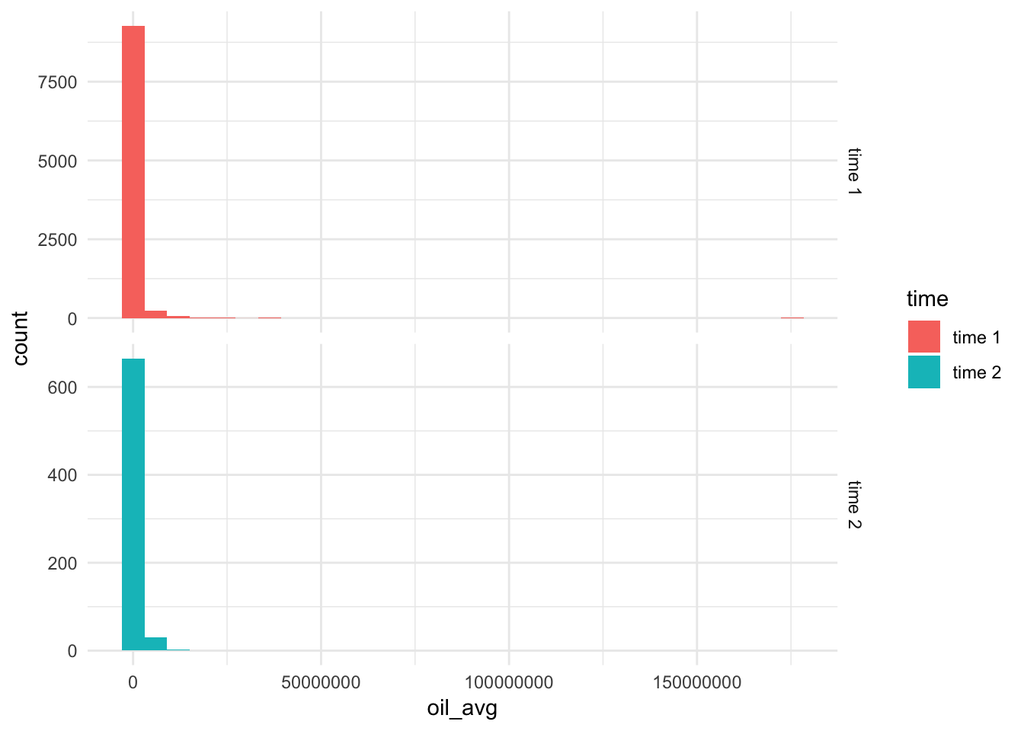

```r
ggplot(data_long, aes(oil_avg, fill = time)) +
  facet_grid(rows = vars(time), scales = "free") +
  geom_histogram(position = "dodge") +
  theme_minimal()
```

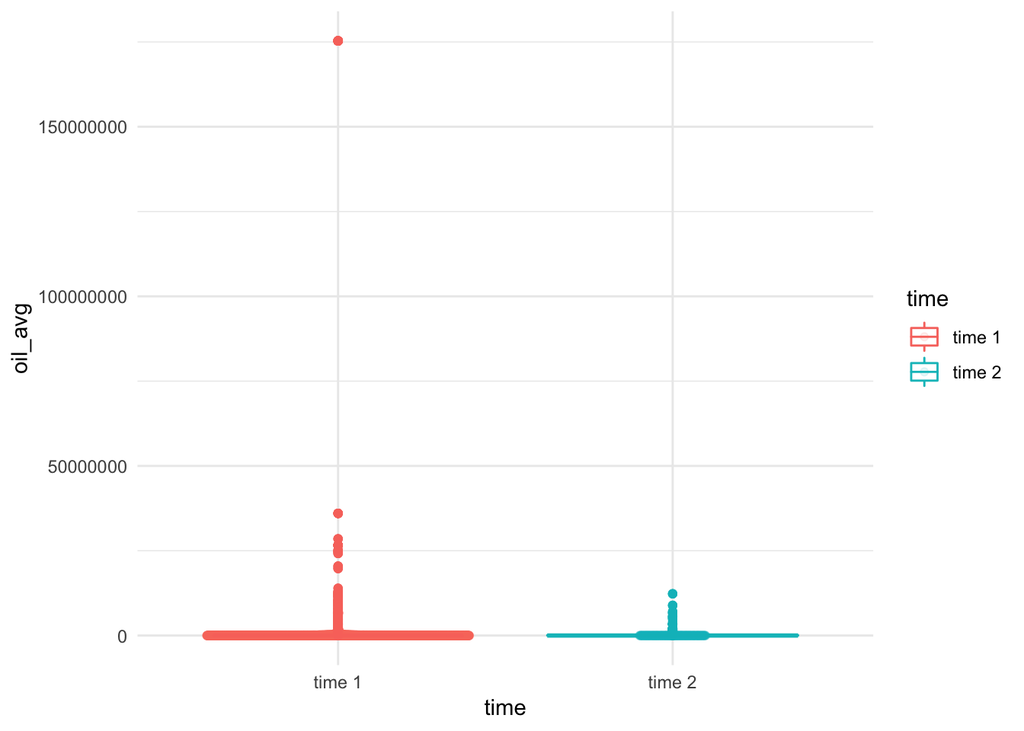

```r
ggplot(data_long, aes(time, oil_avg, colour = time)) +
  geom_boxplot() +
  geom_quasirandom(alpha = 1/10, varwidth = TRUE) +
  theme_minimal()
```

#### Look at only those with oil production only, 90th percentile cutoff

- The distirbution of oil production is in general higher in time 2 compared to time 1 for tribes in counties with oil production only

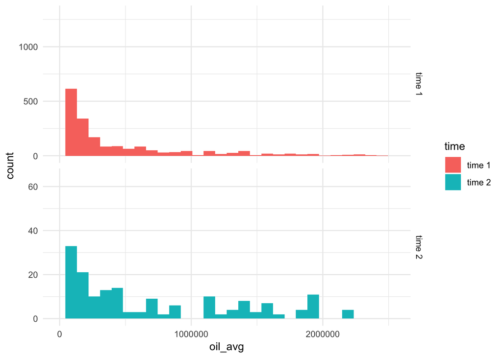

```r
data_long_oil_only <- filter(data_long, oil_avg > 0)

ggplot(data_long_oil_only, aes(oil_avg, fill = time)) +
  facet_grid(rows = vars(time), scales = "free") +
  geom_histogram(position = "dodge") +
  theme_minimal() +
  xlim(0, quantile(data_long_oil_only$oil_avg, c(.90), na.rm = TRUE))
```

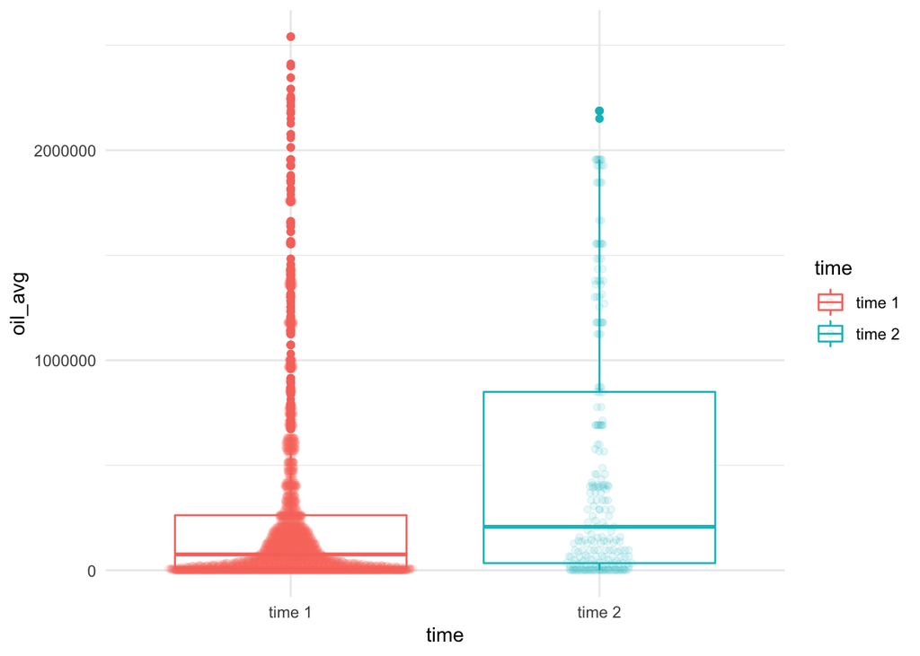

```r
ggplot(data_long_oil_only, aes(time, oil_avg, colour = time)) +
  geom_boxplot() +
  geom_quasirandom(alpha = 1/10, varwidth = TRUE) +
  theme_minimal() +
  ylim(0, quantile(data_long_oil_only$oil_avg, c(.90), na.rm = TRUE))
```

### Tribes with both time 1 or time 2 data

- The distribution of oil production in time 1 and time 2 is skewed to the right, zero-inflated, and with notable outliers.

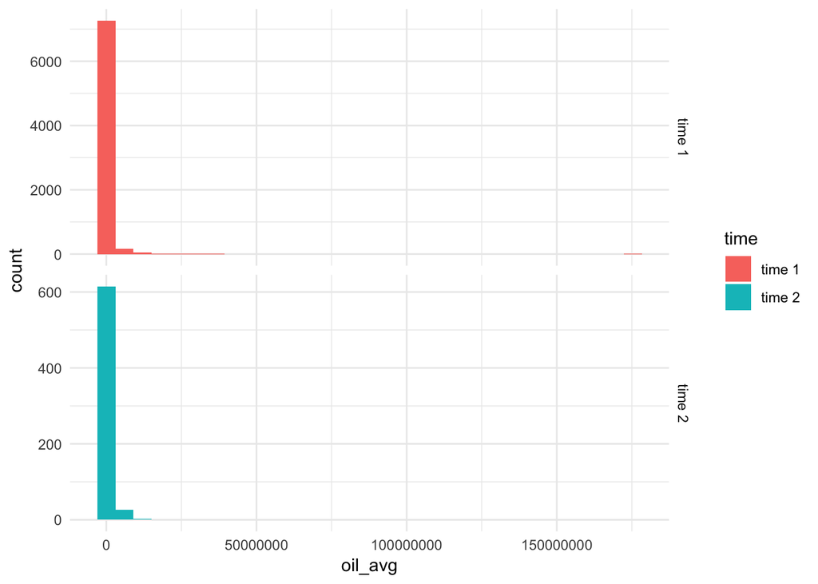

```r
ggplot(data_t1and2_long, aes(oil_avg, fill = time)) +
  facet_grid(rows = vars(time), scales = "free") +
  geom_histogram(position = "dodge") +
  theme_minimal()
```

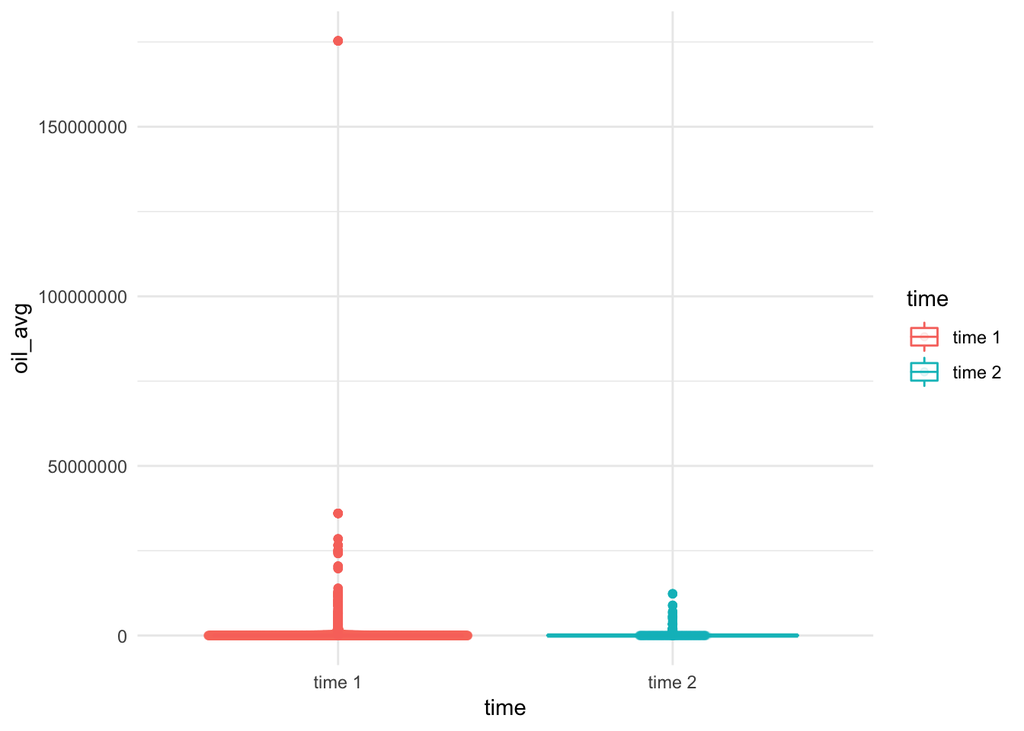

```r
ggplot(data_t1and2_long, aes(time, oil_avg, colour = time)) +
  geom_boxplot() +
  geom_quasirandom(alpha = 1/10, varwidth = TRUE) +
  theme_minimal()
```

#### Look at only those with oil production only, 90th percentile cutoff

- The distirbution of oil production is in general higher in time 2 compared to time 1 for tribes in counties with oil production only

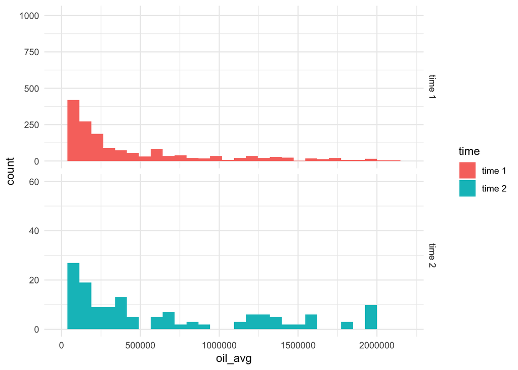

```r
data_t1and2_long_oil_only <- filter(data_t1and2_long, oil_avg > 0)

ggplot(data_t1and2_long_oil_only, aes(oil_avg, fill = time)) +
  facet_grid(rows = vars(time), scales = "free") +
  geom_histogram(position = "dodge") +
  theme_minimal() +
  xlim(0, quantile(data_t1and2_long_oil_only$oil_avg, c(.90), na.rm = TRUE))
```

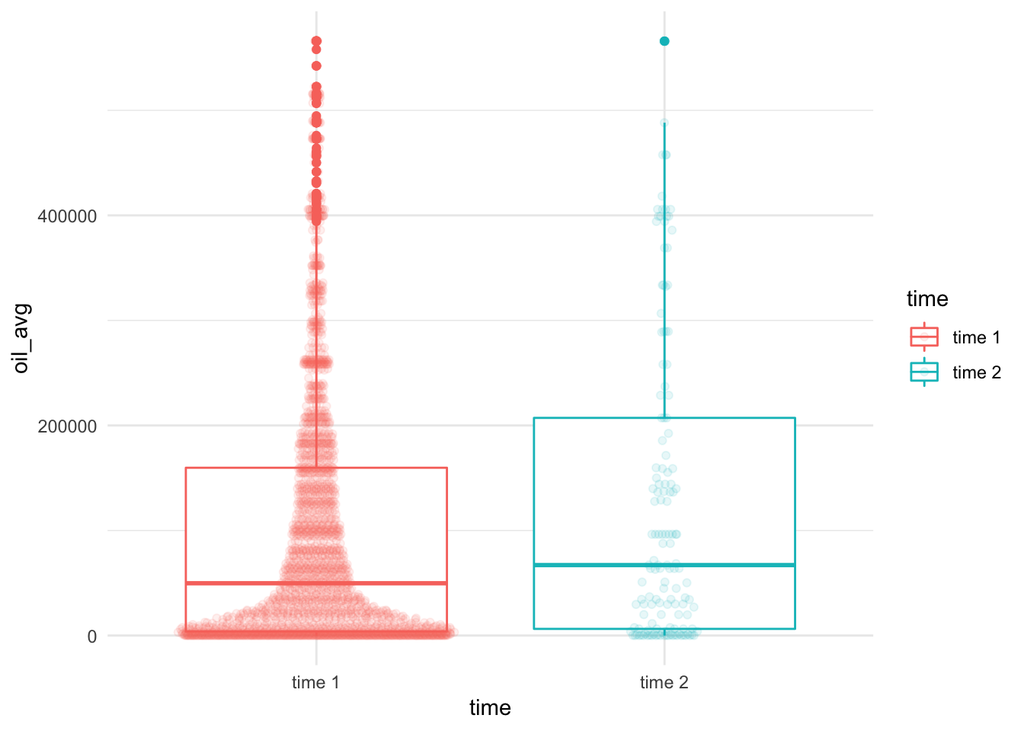

```r
ggplot(data_t1and2_long_oil_only, aes(time, oil_avg, colour = time)) +
  geom_boxplot() +
  geom_quasirandom(alpha = 1/10, varwidth = TRUE) +
  theme_minimal() +
  ylim(0, quantile(data_t1and2_long$oil_avg, c(.90), na.rm = TRUE))
```

## Test for Significant Difference

### (1) Test for significant difference at the aggregate level

- Welch’s t-test (t.test, paired = FALSE) is a parameteric test for two-sample mean comparisions that does not assume equal variance.
- Use Welch’s t-test because the outcome oil production is a continous measures.
- Welch’s t-test for dependent sample is not used because these are not true paired data, since we don’t know which time 1 locations migrate to which time 2 locations and simply assume all possible migration routes happened.

### Use all records

```r
ttest_model <- t.test(oil_avg ~ time, data = data_long, paired = FALSE)

ttest_model
```

```
##
##  Welch Two Sample t-test
##
## data:  oil_avg by time
## t = 3.3049, df = 6177, p-value = 0.0009554
## alternative hypothesis: true difference in means is not equal to 0
## 95 percent confidence interval:
##  135930.7 532290.2
## sample estimates:
## mean in group time 1 mean in group time 2
##             783268.1             449157.7
```

```r
ttest_model <- tidy(ttest_model)

mean_t1 <- round(mean(filter(data_long, time == "time 1")$oil_avg, na.rm = T), 2)
mean_t2 <- round(mean(filter(data_long, time == "time 2")$oil_avg, na.rm = T), 2)
sd_t1 <- round(sd(filter(data_long, time == "time 1")$oil_avg, na.rm = T), 2)
sd_t2 <- round(sd(filter(data_long, time == "time 2")$oil_avg, na.rm = T), 2)

pvalue <- round(ttest_model$p.value, 3)
tvalue <- round(ttest_model$statistic, 3)
degreef <- round(ttest_model$parameter, 3)
```

**Interpretation**

- At the aggregate level, the difference in oil production between time 1 (M = 783268.12, SD = 8452270.23) and time 2 (M = 449157.7, SD = 1395469.86) was statistically signficant (t(6176.973)= 3.305, p = 0.001).

### Use only records where tribes have time 1 and 2 data

```r
ttest_model <- t.test(oil_avg ~ time, data = data_t1and2_long, paired = FALSE)

ttest_model
```

```
##
##  Welch Two Sample t-test
##
## data:  oil_avg by time
## t = 1.4818, df = 2890.4, p-value = 0.1385
## alternative hypothesis: true difference in means is not equal to 0
## 95 percent confidence interval:
##  -39888.0 286692.1
## sample estimates:
## mean in group time 1 mean in group time 2
##             552901.8             429499.7
```

```r
ttest_model <- tidy(ttest_model)

mean_t1 <- round(mean(filter(data_t1and2_long, time == "time 1")$oil_avg, na.rm = T), 0)
mean_t2 <- round(mean(filter(data_t1and2_long, time == "time 2")$oil_avg, na.rm = T), 0)
sd_t1 <- round(sd(filter(data_t1and2_long, time == "time 1")$oil_avg, na.rm = T), 0)
sd_t2 <- round(sd(filter(data_t1and2_long, time == "time 2")$oil_avg, na.rm = T), 0)

pvalue <- round(ttest_model$p.value, 3)
tvalue <- round(ttest_model$statistic, 3)
degreef <- round(ttest_model$parameter, 3)
```

**Interpretation**

- At the aggregate level for tribes with migration, the difference in oil production between time 1 (M = 552902 SD = 5391697) and time 2 (M = 429500, SD = 1405964) was not statistically signficant (t(2890.438)= 1.482, p = 0.138).

### (NEW) Test for significant difference at the aggregate level

### Alternative Test - Using Repeated Measure ANOVA

Restructure data for repeated measure ANOVA and convert tribe and time as factor for modeling

```r
data_wide <- filter(merged_data_record_all, time == "Time 1 and 2")

oil_data_wide <- select(data_wide, ID, tribe, FIPS_t1, FIPS_t2, time, oil_avg_t1, oil_avg_t2, oil_change_score) %>%
  filter(!is.na(oil_avg_t1), !is.na(oil_avg_t2))

oil_data_long <- gather(oil_data_wide, "time", "oil", -ID, -tribe, -time, -oil_change_score, -FIPS_t1, -FIPS_t2) %>% ungroup() %>%
  mutate(tribe = factor(tribe),
         time = factor(time))
```

### Repeated Measure ANOVA

- If we assume pairwise migrations between counties occured for each tribe, Repeated Measure ANOVA is a parameteric test appropriate for making paired sample mean comparisions over time.
- Use Repeated Measure ANOVA because the outcome oil production is a continous measures and is predicted by a single within subject factor (time).
- Repeated Measure ANOVA can only be run with tribes with both time 1 and time 2 data.

### Use only records where tribes have time 1 and 2 data

```r
aov_model <- aov(oil ~ time + Error(tribe / time), data = oil_data_long)

summary(aov_model)
```

```
##
## Error: tribe
##            Df            Sum Sq         Mean Sq F value Pr(>F)
## Residuals 183 54861717447793800 299790805725649
##
## Error: tribe:time
##            Df            Sum Sq         Mean Sq F value Pr(>F)
## time        1     3246849589998   3246849589998   0.025  0.875
## Residuals 183 24075923142606936 131562421544300
##
## Error: Within
##               Df             Sum Sq       Mean Sq F value Pr(>F)
## Residuals 119574 738877222967341440 6179246516528
```

```r
aov_model <- tidy(aov_model)

pvalue <- round(aov_model$p.value[2], 3)
Fvalue <- round(aov_model$statistic[2], 2)
degreef1 <- aov_model$df[2]
degreef2 <- aov_model$df[3]
```

**Interpretation**

- At the aggregate level for tribes with migration, the difference in oil production between time 1 (M = 552902 SD = 5391697) and time 2 (M = 429500, SD = 1405964) was not statistically signficant (F(1, 183)= 0.02, p = 0.875).

### (2) Test for significant difference at tribe level

```r
no_test <- group_by(data_t1and2_long, tribe) %>%
do(tryCatch( {tidy(t.test(oil_avg ~ time, data = ., paired = FALSE))},
  error = function(e) {tidy(t.test(oil_avg ~ time, data = data_t1and2_long)) %>% mutate(estimate = NA)}
    ))

no_test[!!rowSums(is.na(no_test)),-1] <- NA

no_test <- no_test %>%
  filter(!is.na(p.value)) %>%
  nrow()
```

This can only be tested with the 184 tribes where migrations occured. Furthermore, only tribes where oil production have changed between time points and with more than one data point at each time point can their differences be tested for statistical significance. This reduce the number of tribes from 184 to 67.

### Run Welch’s t-test in Batch

- Run Welch’s t-test in batch using group_by and do at the tribe level.
- Include a try call to catch error.
- Use tidy from broom package to format the results into a data.frame.
- Replace NA estimate with all NA for that comparison.

```r
model <- group_by(data_t1and2_long, tribe) %>%
do(tryCatch( {tidy(t.test(oil_avg ~ time, data = ., paired = FALSE))},
  error = function(e) {tidy(t.test(oil_avg ~ time, data = data_t1and2_long)) %>% mutate(estimate = NA)}
    ))

model[!!rowSums(is.na(model)),-1] <- NA
```

Calculate number of test based only on tribes where there is non-zero difference in oil production between time 1 and 2.

```r
no_test <- nrow(filter(model, !is.na(p.value)))
```

```r
model <- model %>%
  mutate(sig = ifelse(p.value < .05 / no_test, "yes", "no"))
```

- Add average oil production, distance, and no of unique FIPS to help with interpretation
- Rename some variables for prettier column headers

```r
results_df <- inner_join(model, merged_data_tribe, by = "tribe") %>%
  mutate(`Avg Diff Oil` = avg_oil_avg_t2 - avg_oil_avg_t1) %>%
  select(tribe, sig, p.value, `Avg Diff Oil`, avg_oil_avg_t1, avg_oil_avg_t2, n_unique_FIPS_t1, n_unique_FIPS_t2, mid_dist) %>%
  arrange(p.value) %>%
  rename(
    `Avg Oil T1` = avg_oil_avg_t1,
    `Avg Oil T2` = avg_oil_avg_t2,
    `Unique FIPS T1` = n_unique_FIPS_t1,
    `Unique FIPS T2` = n_unique_FIPS_t2,
    `Mid Distance` = mid_dist)
```

### Results Table

#### Ordered by p value in ascending order

```r
datatable(results_df,
          filter = "top",
          options = list(pageLength = 20)) %>%
   formatRound(columns = c('p.value'), digits = 3) %>%
   formatRound(columns = c('Avg Diff Oil', 'Avg Oil T1', 'Avg Oil T2', 'Mid Distance'), digits = 2)
```

|  | tribe | sig | p.value | Avg Diff Oil | Avg Oil T1 | Avg Oil T2 | Unique FIPS T1 | Unique FIPS T2 | Mid Distance |
| --- | --- | --- | --- | --- | --- | --- | --- | --- | --- |
| 1 | Choctaw | yes | 0.000200380308276817 | -385905.725 | 461364.6 | 75458.875 | 125 | 16 | 146.342424553144 |
| 2 | Sisseton | no | 0.00163926017380718 | -307407.687763713 | 307407.687763713 | 0 | 238 | 7 |  |
| 3 | Gros Ventre | no | 0.00298880040968277 | -1519053.84 | 1633408.34 | 114354.5 | 50 | 2 | 180.328876444923 |
| 4 | Crow | no | 0.00332599468106214 | -1134341.14583333 | 1162222.14583333 | 27881 | 48 | 3 | 95.8564600158628 |
| 5 | Lenape | no | 0.0203055784601518 | 1294451.96611296 | 55478.176744186 | 1349930.14285714 | 215 | 7 | 1329.2066718248 |
| 6 | Kickapoo | no | 0.0238188448009251 | 1145983.81595092 | 74490.1840490797 | 1220474 | 163 | 5 | 1110.84350984086 |
| 7 | Oneida | no | 0.0389615546019567 | -57425.34375 | 57425.34375 | 0 | 31 | 3 | 440.374949633172 |
| 8 | Mescalero Apache | no | 0.0530387645720428 | -1879169.78723404 | 1879169.78723404 | 0 | 47 | 2 | 58.6348260858404 |
| 9 | Iowa | no | 0.0602824948775632 | 768910.424092409 | 33328.7425742574 | 802239.166666667 | 101 | 6 | 543.034579544272 |
| 10 | Creek | no | 0.0710679526307881 | 506595.154040404 | 137182.595959596 | 643777.75 | 99 | 12 | 870.082238418784 |

[output cut: 174 more lines]

```r
b_sig_tribe_lst <- filter(results_df, sig == "yes") %>%
  select(tribe)
sig_tribe_lst <- filter(results_df, p.value < .05) %>%
  select(tribe)
```

**Interpretation**

- The mean oil production comparisons for 1 tribe (Choctaw) achieve statistical significance when the Bonferroni correction is used.
- The tests have low statistical power to detect differences given the number of observations at time 2 is much smaller than time 1.
- If Bonferroni correction is not used, oil production was significantly differ between time 1 and 2 for 7 tribes :(Choctaw, Sisseton, Gros Ventre, Crow, Lenape, Kickapoo, Oneida).
- Results with NA p values are from tribes where there isn’t sufficient data points in both time point to perform the planned statistical tests (t-test).

**Overall Interpretation**

- Overall, a statistically significant difference was found at the aggregate level when looking at all tribes data, but not when looking at just those with migrations. At the tribe level, when correction for multiple comparisons was made, oil production for 1 tribe were found to be statistically differ between time 1 and time 2. Without correction, oil production was found to be statistically differ for 7 tribes.
- The lack of significant differences at the tribe level could be attributed to the low statistical power arises from the small number of observations at time 2. In some cases, there is only 1 data point in time 2 or time 1, which preclude the use of t-test to test for their mean differences.

### (NEW) Run Repeated Measure ANOVA in Batch

- Run repeated measure ANOVA in batch using group_by and do at the tribe level.
- Include a try call to catch error.
- Use tidy from broom package to format the results into a data.frame.
- Replace NA estimate with all NA for that comparison.
- Filter out tribes where test cannot be run due to insufficient sample size.

```r
model <- group_by(oil_data_long, tribe) %>%
do(tryCatch( {tidy(aov(oil ~ time + Error(ID / time), data = .))},
  error = function(e) {tidy((aov(oil ~ time + Error(ID / time), data = .))) %>% mutate(estimate = NA)}
    ))

model[!!rowSums(is.na(model)),-1] <- NA

model <- filter(model, stratum == "Within", term == "time")
```

Calculate number of test based only on tribes where there is non-zero difference in oil production between time 1 and 2.

```r
no_test <- nrow(filter(model, !is.na(p.value)))
```

```r
model <- model %>%
  mutate(sig = ifelse(p.value < .05 / no_test, "yes", "no"))
```

- Add average oil production, distance, and no of unique FIPS to help with interpretation
- Rename some variables for prettier column headers

```r
results_df <- inner_join(model, merged_data_tribe, by = "tribe") %>%
  mutate(`Avg Diff Oil` = avg_oil_avg_t2 - avg_oil_avg_t1) %>%
  select(tribe, sig, p.value, `Avg Diff Oil`, avg_oil_avg_t1, avg_oil_avg_t2, n_unique_FIPS_t1, n_unique_FIPS_t2, mid_dist) %>%
  arrange(p.value) %>%
  rename(
    `Avg Oil T1` = avg_oil_avg_t1,
    `Avg Oil T2` = avg_oil_avg_t2,
    `Unique FIPS T1` = n_unique_FIPS_t1,
    `Unique FIPS T2` = n_unique_FIPS_t2,
    `Mid Distance` = mid_dist)
```

### Results Table

#### Ordered by p value in ascending order

```r
datatable(results_df,
          filter = "top",
          options = list(pageLength = 20)) %>%
   formatRound(columns = c('p.value'), digits = 3) %>%
   formatRound(columns = c('Avg Diff Oil', 'Avg Oil T1', 'Avg Oil T2', 'Mid Distance'), digits = 2)
```

|  | tribe | sig | p.value | Avg Diff Oil | Avg Oil T1 | Avg Oil T2 | Unique FIPS T1 | Unique FIPS T2 | Mid Distance |
| --- | --- | --- | --- | --- | --- | --- | --- | --- | --- |
| 1 | Lenape | yes | 6.43559013313281e-120 | 1294451.96611296 | 55478.176744186 | 1349930.14285714 | 215 | 7 | 1329.2066718248 |
| 2 | Kickapoo | yes | 1.60603499024472e-113 | 1145983.81595092 | 74490.1840490797 | 1220474 | 163 | 5 | 1110.84350984086 |
| 3 | Absentee-Shawnee | yes | 2.34789416163169e-81 | 1226970.17021277 | 63550.4964539007 | 1290520.66666667 | 141 | 3 | 1171.77025062068 |
| 4 | Potawatomi | yes | 1.69296093582623e-46 | 270526.749090909 | 54434.2509090909 | 324961 | 275 | 13 | 288.610536701408 |
| 5 | Otoe | yes | 4.69770377614774e-39 | 783459.62962963 | 7635.37037037037 | 791095 | 81 | 2 | 639.736788865344 |
| 6 | Iowa | yes | 3.37062224792056e-37 | 768910.424092409 | 33328.7425742574 | 802239.166666667 | 101 | 6 | 543.034579544272 |
| 7 | Osage | yes | 6.82804456513241e-31 | 3662772.7689243 | 446814.231075697 | 4109587 | 250 | 1 | 175.296403761868 |
| 8 | Chippewa | yes | 4.26067633556058e-28 | 48217.5961918105 | 104845.428198433 | 153063.024390244 | 383 | 41 | 535.353093075632 |
| 9 | Shoshone | yes | 4.96489332094291e-23 | 55648.35 | 333281.15 | 388929.5 | 80 | 18 | 82.6915019161039 |
| 10 | Missouria | yes | 5.93484027268383e-23 | 778968.235294118 | 12126.7647058824 | 791095 | 51 | 2 | 557.102962954828 |

[output cut: 82 more lines]

```r
b_sig_tribe_lst <- filter(results_df, sig == "yes") %>%
  select(tribe)
sig_tribe_lst <- filter(results_df, p.value < .05) %>%
  select(tribe)
```

**Interpretation**

- The mean oil production comparisons for 26 tribes (Lenape, Kickapoo, Absentee-Shawnee, Potawatomi, Otoe, Iowa, Osage, Chippewa, Shoshone, Missouria, Chickasaw, Pawnee, Sioux, Ottawa, Seminole, Paiute, Appalachicola, Creek, Ute, Comanche, Kiowa, Peoria, Me-Wuk, Seneca, Kaskaskia, Goshute) achieve statistical significance when the Bonferroni correction is used.
- The tests has low statistical power to detect differences given the number of observations at time 2 is much smaller than time 1.
- If Bonferroni correction is not used, oil production was significantly differ between time 1 and 2 for 50 tribes :(Lenape, Kickapoo, Absentee-Shawnee, Potawatomi, Otoe, Iowa, Osage, Chippewa, Shoshone, Missouria, Chickasaw, Pawnee, Sioux, Ottawa, Seminole, Paiute, Appalachicola, Creek, Ute, Comanche, Kiowa, Peoria, Me-Wuk, Seneca, Kaskaskia, Goshute, Kaw, Wyandotte, Cayuga, Cheyenne, Shawnee, Pomo, Luiseno, Cherokee, Kalispel, Cahuilla, Yavapai, Chukchansi, Kootenai, Arikara, Cupeno, Mission, Choctaw, Yokut, Mono, Flathead, Salish, Nez Perce, Maidu, Yankton Sioux).
- Of the 184 tribes with migrations, 92 has insufficient data points in both time points to perform the planned statistical tests (repeated measure ANOVA).

**Overall Interpretation**

- Overall, a statistically significant difference was not found at the aggregate level. At the tribe level, when correction for multiple comparisons was made, oil production for 26 tribes were found to be statistically differ between time 1 and time 2. Without correction, oil production was found to be statistically differ for 50 tribes.
- The lack of significant differences at the tribe level could be attributed to the low statistical power arises from the small number of observations at time 2. In some cases, there is only 1 data point in time 2 or time 1, which preclude the use of repeated measure ANOVA to test for their mean differences.
- Between the two set of tests (independent t-test and repeated measure ANOVA), the independent tests is more conservative when come to achieving statistical significance and the repeated measures ANOVA is more powerful in detecting observed differences in paired data. The repeated measure tests also have more significant findings because we have many more observations by using all-pairs and partialling out the intra-correlations.